# CMSC320 Final Project

David Wang, Steve Jettoo

## Ingesting and Tidying Data

```r
library(tidyverse)
library(rvest)
library(dplyr)
library(tidyr)
library(stringr)
library(crypto)
```

```r
crypto_hist <- crypto_history(coin = "bitcoin", limit = NULL, start_date = "20170427", end_date ="20190228")
```

[output not shown]

[output not shown]

[output not shown]

```
## > Scraping historical crypto data
```

```r
colnames(crypto_hist)[colnames(crypto_hist)=="date"] <- "Date"

crypto_hist
```

| slug | symbol | name | Date | ranknow | open | high | low | close | volume | market | close_ratio | spread |
| --- | --- | --- | --- | --- | --- | --- | --- | --- | --- | --- | --- | --- |
| bitcoin | BTC | Bitcoin | 2017-04-27 | 1 | 1281.88 | 1319.70 | 1281.30 | 1317.73 | 449196992 | 21475836448 | 0.948697917 | 38.40 |
| bitcoin | BTC | Bitcoin | 2017-04-28 | 1 | 1317.74 | 1331.28 | 1292.37 | 1316.48 | 527488992 | 21457669552 | 0.619635055 | 38.91 |
| bitcoin | BTC | Bitcoin | 2017-04-29 | 1 | 1317.84 | 1327.20 | 1315.21 | 1321.79 | 422705984 | 21547126640 | 0.548790659 | 11.99 |
| bitcoin | BTC | Bitcoin | 2017-04-30 | 1 | 1321.87 | 1347.91 | 1314.92 | 1347.89 | 413115008 | 21975104909 | 0.999393756 | 32.99 |
| bitcoin | BTC | Bitcoin | 2017-05-01 | 1 | 1348.30 | 1434.32 | 1348.30 | 1421.60 | 713624000 | 23179524919 | 0.852127412 | 86.02 |
| bitcoin | BTC | Bitcoin | 2017-05-02 | 1 | 1421.03 | 1473.90 | 1415.69 | 1452.82 | 477337984 | 23691443738 | 0.637862910 | 58.21 |
| bitcoin | BTC | Bitcoin | 2017-05-03 | 1 | 1453.78 | 1492.77 | 1447.49 | 1490.09 | 583795968 | 24301634925 | 0.940812721 | 45.28 |
| bitcoin | BTC | Bitcoin | 2017-05-04 | 1 | 1490.72 | 1608.91 | 1490.72 | 1537.67 | 933548992 | 25080858487 | 0.397241729 | 118.19 |
| bitcoin | BTC | Bitcoin | 2017-05-05 | 1 | 1540.87 | 1618.03 | 1530.31 | 1555.45 | 946035968 | 25373374563 | 0.286593707 | 87.72 |
| bitcoin | BTC | Bitcoin | 2017-05-06 | 1 | 1556.81 | 1578.80 | 1542.50 | 1578.80 | 582529984 | 25757608890 | 1.000000000 | 36.30 |

[output cut: 663 more lines]

```r
library(readxl)

CMSC320_Crypto_Data <- read_excel("CMSC320 Crypto Data.xlsx")
excel_data <- data.frame(CMSC320_Crypto_Data) %>%
   mutate(Date = as.Date(Date, format="%Y-%m-%d"))
excel_data
```

| Date | TxPerDay | AvgFee | Hashrate | Diff | ResElec | CommElec | FFR | Trending | Infl | TT |
| --- | --- | --- | --- | --- | --- | --- | --- | --- | --- | --- |
| 2017-04-27 | 297884 | 256.44730 | 3814282 | 521.8397 | 12.72 | 10.40 | 0.90 | 21 | 2.2 | 1 |
| 2017-04-28 | 305271 | 249.68420 | 3528859 | 521.9745 | 12.72 | 10.40 | 0.90 | 20 | 2.2 | 2 |
| 2017-04-29 | 341319 | 256.37650 | 4488916 | 521.9745 | 12.72 | 10.40 | 0.90 | 19 | 2.2 | 3 |
| 2017-04-30 | 281489 | 199.30760 | 3918072 | 521.9745 | 12.72 | 10.40 | 0.90 | 19 | 2.2 | 4 |
| 2017-05-01 | 294786 | 227.74890 | 3892124 | 521.9745 | 13.07 | 10.59 | 0.91 | 23 | 1.9 | 5 |
| 2017-05-02 | 333161 | 272.67970 | 4099704 | 521.9745 | 13.07 | 10.59 | 0.91 | 26 | 1.9 | 6 |
| 2017-05-03 | 295149 | 247.34370 | 3425069 | 521.9745 | 13.07 | 10.59 | 0.91 | 25 | 1.9 | 7 |
| 2017-05-04 | 354737 | 307.09570 | 4359179 | 521.9745 | 13.07 | 10.59 | 0.91 | 33 | 1.9 | 8 |
| 2017-05-05 | 267193 | 261.31170 | 3347227 | 521.9745 | 13.07 | 10.59 | 0.91 | 32 | 1.9 | 9 |
| 2017-05-06 | 363022 | 296.57370 | 4359179 | 521.9745 | 13.07 | 10.59 | 0.91 | 25 | 1.9 | 10 |

[output cut: 716 more lines]

Next, read the data from “CMSC320 Crypto Data.xlsx”. This dataset is an excel spreadsheet. The data within the excel spreadsheet is data from various sources.

These are the attributes within the dataset and a short explanation of what they are: TxPerDay: Number of Transaction over a 24 hour period. AvgFee: Daily aggregate fee added to transaction (transaction cost) Hashrate: Daily relative measure of network’s processing power in trillions of terahashes per second Diff: Daily mathematical value of how hard it is to find a valid hash for a block ResElec: Daily residential Electricity Price in cents/kWh CommElec: Daily commercial Electricity Price in cents/kWh FFR: Federal Funds Rate or the interest rate at which banks lend reserve balances to other banks overnight Trending: Daily measure of interest in bitcoin over time (from Google trends) Infl: Inflation Rate; used as a macroeconomic indicator on the impact of price changes on Bitcoin value TT: A unique identifier for every observation

To import an excel spreadsheet onto R, one must first have the package library readxl installed. The package readxl allows R to easily access the data within Excel. We will use the function ‘read_excel’ to read the xlsx file. Once we have the excel file in R, we will transform it so that it becomes a data frame. This is so we are able to manipulate the data within the excel sheet. We will use the function ‘data.frame’ to transform the xlsx file into a data frame.

Once the Date attribute has been converted into type date, we now have a data set that can be merged with our previous dataset.

```r
crypto_merge <- crypto_hist %>%
  left_join(excel_data, by = "Date")
crypto_merge
```

| slug | symbol | name | Date | ranknow | open | high | low | close | volume | market | close_ratio | spread | TxPerDay | AvgFee | Hashrate | Diff | ResElec | CommElec | FFR | Trending | Infl | TT |
| --- | --- | --- | --- | --- | --- | --- | --- | --- | --- | --- | --- | --- | --- | --- | --- | --- | --- | --- | --- | --- | --- | --- |
| bitcoin | BTC | Bitcoin | 2017-04-27 | 1 | 1281.88 | 1319.70 | 1281.30 | 1317.73 | 449196992 | 21475836448 | 0.948697917 | 38.40 | 297884 | 256.44730 | 3814282 | 521.8397 | 12.72 | 10.40 | 0.90 | 21 | 2.2 | 1 |
| bitcoin | BTC | Bitcoin | 2017-04-28 | 1 | 1317.74 | 1331.28 | 1292.37 | 1316.48 | 527488992 | 21457669552 | 0.619635055 | 38.91 | 305271 | 249.68420 | 3528859 | 521.9745 | 12.72 | 10.40 | 0.90 | 20 | 2.2 | 2 |
| bitcoin | BTC | Bitcoin | 2017-04-29 | 1 | 1317.84 | 1327.20 | 1315.21 | 1321.79 | 422705984 | 21547126640 | 0.548790659 | 11.99 | 341319 | 256.37650 | 4488916 | 521.9745 | 12.72 | 10.40 | 0.90 | 19 | 2.2 | 3 |
| bitcoin | BTC | Bitcoin | 2017-04-30 | 1 | 1321.87 | 1347.91 | 1314.92 | 1347.89 | 413115008 | 21975104909 | 0.999393756 | 32.99 | 281489 | 199.30760 | 3918072 | 521.9745 | 12.72 | 10.40 | 0.90 | 19 | 2.2 | 4 |
| bitcoin | BTC | Bitcoin | 2017-05-01 | 1 | 1348.30 | 1434.32 | 1348.30 | 1421.60 | 713624000 | 23179524919 | 0.852127412 | 86.02 | 294786 | 227.74890 | 3892124 | 521.9745 | 13.07 | 10.59 | 0.91 | 23 | 1.9 | 5 |
| bitcoin | BTC | Bitcoin | 2017-05-02 | 1 | 1421.03 | 1473.90 | 1415.69 | 1452.82 | 477337984 | 23691443738 | 0.637862910 | 58.21 | 333161 | 272.67970 | 4099704 | 521.9745 | 13.07 | 10.59 | 0.91 | 26 | 1.9 | 6 |
| bitcoin | BTC | Bitcoin | 2017-05-03 | 1 | 1453.78 | 1492.77 | 1447.49 | 1490.09 | 583795968 | 24301634925 | 0.940812721 | 45.28 | 295149 | 247.34370 | 3425069 | 521.9745 | 13.07 | 10.59 | 0.91 | 25 | 1.9 | 7 |
| bitcoin | BTC | Bitcoin | 2017-05-04 | 1 | 1490.72 | 1608.91 | 1490.72 | 1537.67 | 933548992 | 25080858487 | 0.397241729 | 118.19 | 354737 | 307.09570 | 4359179 | 521.9745 | 13.07 | 10.59 | 0.91 | 33 | 1.9 | 8 |
| bitcoin | BTC | Bitcoin | 2017-05-05 | 1 | 1540.87 | 1618.03 | 1530.31 | 1555.45 | 946035968 | 25373374563 | 0.286593707 | 87.72 | 267193 | 261.31170 | 3347227 | 521.9745 | 13.07 | 10.59 | 0.91 | 32 | 1.9 | 9 |
| bitcoin | BTC | Bitcoin | 2017-05-06 | 1 | 1556.81 | 1578.80 | 1542.50 | 1578.80 | 582529984 | 25757608890 | 1.000000000 | 36.30 | 363022 | 296.57370 | 4359179 | 521.9745 | 13.07 | 10.59 | 0.91 | 25 | 1.9 | 10 |

[output cut: 664 more lines]

We will now merge the two datasets together using their Date attribute. To do this, we will be using the ‘join’ operation. The ‘join’ operation allows us to merge the rows of two data sets forming one data set, given a matching attribute from the two data sets. The join operation that we will be mainly using is the ‘left_join’ operation. ‘left_join’ will merge the two data sets together; however, all observations on the left hand side or the first data set are retained.

We will merge the data set excel_data onto the data set crypto_hist using the common attribute “Date” with the function ‘left_join’. This will create one data set that contains the data from both data sets. We will call this new data set, crypto_merge.

```r
# Gets stock data from yahoo
# install.packages("quantmod")

library(quantmod)
# Scrape Data from yahoo finance
getSymbols("^DJI", from = "2017-4-27", to = "2019-2-28")
```

[output not shown]

```
## [1] "^DJI"
```

```r
# Set it as a data frame
DJI_data <- data.frame(DJI)
DJI_data
```

|  | DJI.Open | DJI.High | DJI.Low | DJI.Close | DJI.Volume | DJI.Adjusted |
| --- | --- | --- | --- | --- | --- | --- |
| 2017-04-27 | 20991.12 | 21005.80 | 20935.80 | 20981.33 | 305690000 | 20981.33 |
| 2017-04-28 | 20987.39 | 20987.76 | 20926.75 | 20940.51 | 329990000 | 20940.51 |
| 2017-05-01 | 20962.73 | 20976.62 | 20898.38 | 20913.46 | 288160000 | 20913.46 |
| 2017-05-02 | 20941.19 | 20960.92 | 20904.06 | 20949.89 | 338810000 | 20949.89 |
| 2017-05-03 | 20915.00 | 20972.74 | 20874.18 | 20957.90 | 310920000 | 20957.90 |
| 2017-05-04 | 20987.83 | 20990.79 | 20847.95 | 20951.47 | 274720000 | 20951.47 |
| 2017-05-05 | 20929.04 | 21006.94 | 20905.00 | 21006.94 | 260960000 | 21006.94 |
| 2017-05-08 | 20991.26 | 21017.89 | 20971.05 | 21012.28 | 276150000 | 21012.28 |
| 2017-05-09 | 21022.28 | 21046.85 | 20938.04 | 20975.78 | 273000000 | 20975.78 |
| 2017-05-10 | 20958.49 | 20976.28 | 20884.15 | 20943.11 | 283340000 | 20943.11 |

[output cut: 452 more lines]

We will now injest stock market data. To do this we require the quantmod package. The quantmod package allows us to easily access stock data in R. For this project, we want stock information about the Dow Jones Industrial Average (^DJI). To get this information, we will use the function ‘getSymbols’ from the quantmod package. The ‘getSymbols’ function allows us to load and manage ‘Symbols’ in a specified enviroment. We will use it to obtain stock data for the Dow Jones Industrial Average. The function ‘getSymbols’ should create an xts object with the name of the stock company when loading the stock data of a specific company. In this case the xts object with the stock data should be named “DJI”. Tranform the xts object into a data frame using data.frame. We will call this DJI_data.

Further Reading for the quantmod package: https://cran.r-project.org/web/packages/quantmod/quantmod.pdf

```r
# Date is set as a row name. We need to change this so that Date becomes an attribute. This will be neccessary if we want to merge the stock data with the bitcoin data

# Add a column name to the dates as well as change the names for the rest of the attributes
DJI_data <- cbind(rownames(DJI_data), DJI_data)

# Removes the row name
rownames(DJI_data) <- NULL
colnames(DJI_data) <- c("Date","DJI_Open","DJI_High", "DJI_Low", "DJI_Close", "DJI_Volume", "DJI_Adjusted")

DJI_data
```

| Date | DJI_Open | DJI_High | DJI_Low | DJI_Close | DJI_Volume | DJI_Adjusted |
| --- | --- | --- | --- | --- | --- | --- |
| 2017-04-27 | 20991.12 | 21005.80 | 20935.80 | 20981.33 | 305690000 | 20981.33 |
| 2017-04-28 | 20987.39 | 20987.76 | 20926.75 | 20940.51 | 329990000 | 20940.51 |
| 2017-05-01 | 20962.73 | 20976.62 | 20898.38 | 20913.46 | 288160000 | 20913.46 |
| 2017-05-02 | 20941.19 | 20960.92 | 20904.06 | 20949.89 | 338810000 | 20949.89 |
| 2017-05-03 | 20915.00 | 20972.74 | 20874.18 | 20957.90 | 310920000 | 20957.90 |
| 2017-05-04 | 20987.83 | 20990.79 | 20847.95 | 20951.47 | 274720000 | 20951.47 |
| 2017-05-05 | 20929.04 | 21006.94 | 20905.00 | 21006.94 | 260960000 | 21006.94 |
| 2017-05-08 | 20991.26 | 21017.89 | 20971.05 | 21012.28 | 276150000 | 21012.28 |
| 2017-05-09 | 21022.28 | 21046.85 | 20938.04 | 20975.78 | 273000000 | 20975.78 |
| 2017-05-10 | 20958.49 | 20976.28 | 20884.15 | 20943.11 | 283340000 | 20943.11 |

[output cut: 452 more lines]

When viewing the stock data for DJI, notice that the dates are row names instead of values. We need to tranform the dates for a row name to a value. This is so we can merge this data set into our crypto_merge data set. To do this we will first use the function ‘cbind’ to create a new attribute using the dates that are row names. We then will remove the row names by setting them to be NULL. Finally, we will rename the column names using the function ‘colnames’.

Here are the attributes and an explanation of what each attribute is for this data set: DJI_Open: The opening price of a stock of the Dow Jones Industrial Average DJI_Close: The closing price of a stock of the Dow Jones Industrial Average DJI_Volume: The number of Dow Jones Industrial Average shares that changed hands during a given day DJI_Adjusted: The adjusted closing price of a stock of the Dow Jones Industrial Average taking into account any corporate actions

```r
getSymbols("NVDA", from = "2017-4-27", to = "2019-2-28")
```

```
## [1] "NVDA"
```

```r
NVDA_data <- data.frame(NVDA)
NVDA_data
```

|  | NVDA.Open | NVDA.High | NVDA.Low | NVDA.Close | NVDA.Volume | NVDA.Adjusted |
| --- | --- | --- | --- | --- | --- | --- |
| 2017-04-27 | 104.32 | 105.98 | 103.59 | 105.64 | 7992500 | 104.9615 |
| 2017-04-28 | 105.36 | 105.64 | 104.07 | 104.30 | 8677600 | 103.6301 |
| 2017-05-01 | 104.74 | 106.85 | 104.45 | 106.64 | 7693300 | 105.9551 |
| 2017-05-02 | 105.55 | 105.60 | 102.56 | 103.48 | 15749300 | 102.8154 |
| 2017-05-03 | 103.20 | 104.64 | 102.60 | 104.25 | 8422600 | 103.5804 |
| 2017-05-04 | 104.50 | 104.95 | 103.53 | 103.85 | 5244700 | 103.1830 |
| 2017-05-05 | 103.38 | 104.15 | 102.75 | 103.86 | 5710700 | 103.1929 |
| 2017-05-08 | 104.34 | 104.40 | 102.31 | 102.77 | 9131000 | 102.1099 |
| 2017-05-09 | 103.00 | 104.93 | 102.66 | 102.94 | 21191800 | 102.2788 |
| 2017-05-10 | 114.29 | 121.82 | 114.02 | 121.29 | 53227400 | 120.5110 |

[output cut: 452 more lines]

We will repeat the same process to ingest and scrape Nvidia stock data. We will use the ‘getSymbols’ function to get Nvidia stock data, and then we will transform it into a data frame. We will call this NVDA_data.

```r
NVDA_data <- cbind(rownames(NVDA_data), NVDA_data)

rownames(NVDA_data) <- NULL
colnames(NVDA_data) <- c("Date","NVDA_Open","NVDA_High", "NVDA_Low", "NVDA_Close", "NVDA_Volume", "NVDA_Adjusted")
NVDA_data
```

| Date | NVDA_Open | NVDA_High | NVDA_Low | NVDA_Close | NVDA_Volume | NVDA_Adjusted |
| --- | --- | --- | --- | --- | --- | --- |
| 2017-04-27 | 104.32 | 105.98 | 103.59 | 105.64 | 7992500 | 104.9615 |
| 2017-04-28 | 105.36 | 105.64 | 104.07 | 104.30 | 8677600 | 103.6301 |
| 2017-05-01 | 104.74 | 106.85 | 104.45 | 106.64 | 7693300 | 105.9551 |
| 2017-05-02 | 105.55 | 105.60 | 102.56 | 103.48 | 15749300 | 102.8154 |
| 2017-05-03 | 103.20 | 104.64 | 102.60 | 104.25 | 8422600 | 103.5804 |
| 2017-05-04 | 104.50 | 104.95 | 103.53 | 103.85 | 5244700 | 103.1830 |
| 2017-05-05 | 103.38 | 104.15 | 102.75 | 103.86 | 5710700 | 103.1929 |
| 2017-05-08 | 104.34 | 104.40 | 102.31 | 102.77 | 9131000 | 102.1099 |
| 2017-05-09 | 103.00 | 104.93 | 102.66 | 102.94 | 21191800 | 102.2788 |
| 2017-05-10 | 114.29 | 121.82 | 114.02 | 121.29 | 53227400 | 120.5110 |

[output cut: 452 more lines]

We will now fix the data so that dates are in an attribute. We will the same process as before.

Here are the attributes and an explanation of what each attribute is for this data set: NVDA_Open: The opening price of a stock of Nvidia NVDA_Close: The closing price of a stock of the Nvidia NVDA_Volume: The number of Nvidia shares that changed hands during a given day NVDA_Adjusted: The adjusted closing price of a stock of the Nvidia taking into account any corporate actions

```r
stock_data <- NVDA_data %>%
  left_join(DJI_data, by="Date") %>%
  mutate(Date = as.Date(Date, format="%Y-%m-%d"))
stock_data
```

| Date | NVDA_Open | NVDA_High | NVDA_Low | NVDA_Close | NVDA_Volume | NVDA_Adjusted | DJI_Open | DJI_High | DJI_Low | DJI_Close | DJI_Volume | DJI_Adjusted |
| --- | --- | --- | --- | --- | --- | --- | --- | --- | --- | --- | --- | --- |
| 2017-04-27 | 104.32 | 105.98 | 103.59 | 105.64 | 7992500 | 104.9615 | 20991.12 | 21005.80 | 20935.80 | 20981.33 | 305690000 | 20981.33 |
| 2017-04-28 | 105.36 | 105.64 | 104.07 | 104.30 | 8677600 | 103.6301 | 20987.39 | 20987.76 | 20926.75 | 20940.51 | 329990000 | 20940.51 |
| 2017-05-01 | 104.74 | 106.85 | 104.45 | 106.64 | 7693300 | 105.9551 | 20962.73 | 20976.62 | 20898.38 | 20913.46 | 288160000 | 20913.46 |
| 2017-05-02 | 105.55 | 105.60 | 102.56 | 103.48 | 15749300 | 102.8154 | 20941.19 | 20960.92 | 20904.06 | 20949.89 | 338810000 | 20949.89 |
| 2017-05-03 | 103.20 | 104.64 | 102.60 | 104.25 | 8422600 | 103.5804 | 20915.00 | 20972.74 | 20874.18 | 20957.90 | 310920000 | 20957.90 |
| 2017-05-04 | 104.50 | 104.95 | 103.53 | 103.85 | 5244700 | 103.1830 | 20987.83 | 20990.79 | 20847.95 | 20951.47 | 274720000 | 20951.47 |
| 2017-05-05 | 103.38 | 104.15 | 102.75 | 103.86 | 5710700 | 103.1929 | 20929.04 | 21006.94 | 20905.00 | 21006.94 | 260960000 | 21006.94 |
| 2017-05-08 | 104.34 | 104.40 | 102.31 | 102.77 | 9131000 | 102.1099 | 20991.26 | 21017.89 | 20971.05 | 21012.28 | 276150000 | 21012.28 |
| 2017-05-09 | 103.00 | 104.93 | 102.66 | 102.94 | 21191800 | 102.2788 | 21022.28 | 21046.85 | 20938.04 | 20975.78 | 273000000 | 20975.78 |
| 2017-05-10 | 114.29 | 121.82 | 114.02 | 121.29 | 53227400 | 120.5110 | 20958.49 | 20976.28 | 20884.15 | 20943.11 | 283340000 | 20943.11 |

[output cut: 452 more lines]

We will now merge the the DJI stock data set with the NVDA stock data set using the ‘left_join’ function with the common attribute “Date”. The two data sets will be merged into one data set that we will call stock_data.

```r
crypto_data <- crypto_merge %>%
  left_join(stock_data, by="Date")
crypto_data
```

| slug | symbol | name | Date | ranknow | open | high | low | close | volume | market | close_ratio | spread | TxPerDay | AvgFee | Hashrate | Diff | ResElec | CommElec | FFR | Trending | Infl | TT | NVDA_Open | NVDA_High | NVDA_Low | NVDA_Close | NVDA_Volume | NVDA_Adjusted | DJI_Open | … |
| --- | --- | --- | --- | --- | --- | --- | --- | --- | --- | --- | --- | --- | --- | --- | --- | --- | --- | --- | --- | --- | --- | --- | --- | --- | --- | --- | --- | --- | --- | --- |
| bitcoin | BTC | Bitcoin | 2017-04-27 | 1 | 1281.88 | 1319.70 | 1281.30 | 1317.73 | 449196992 | 21475836448 | 0.948697917 | 38.40 | 297884 | 256.44730 | 3814282 | 521.8397 | 12.72 | 10.40 | 0.90 | 21 | 2.2 | 1 | 104.32 | 105.98 | 103.59 | 105.64 | 7992500 | 104.9615 | 20991.12 | … |
| bitcoin | BTC | Bitcoin | 2017-04-28 | 1 | 1317.74 | 1331.28 | 1292.37 | 1316.48 | 527488992 | 21457669552 | 0.619635055 | 38.91 | 305271 | 249.68420 | 3528859 | 521.9745 | 12.72 | 10.40 | 0.90 | 20 | 2.2 | 2 | 105.36 | 105.64 | 104.07 | 104.30 | 8677600 | 103.6301 | 20987.39 | … |
| bitcoin | BTC | Bitcoin | 2017-04-29 | 1 | 1317.84 | 1327.20 | 1315.21 | 1321.79 | 422705984 | 21547126640 | 0.548790659 | 11.99 | 341319 | 256.37650 | 4488916 | 521.9745 | 12.72 | 10.40 | 0.90 | 19 | 2.2 | 3 | NA | NA | NA | NA | NA | NA | NA | … |
| bitcoin | BTC | Bitcoin | 2017-04-30 | 1 | 1321.87 | 1347.91 | 1314.92 | 1347.89 | 413115008 | 21975104909 | 0.999393756 | 32.99 | 281489 | 199.30760 | 3918072 | 521.9745 | 12.72 | 10.40 | 0.90 | 19 | 2.2 | 4 | NA | NA | NA | NA | NA | NA | NA | … |
| bitcoin | BTC | Bitcoin | 2017-05-01 | 1 | 1348.30 | 1434.32 | 1348.30 | 1421.60 | 713624000 | 23179524919 | 0.852127412 | 86.02 | 294786 | 227.74890 | 3892124 | 521.9745 | 13.07 | 10.59 | 0.91 | 23 | 1.9 | 5 | 104.74 | 106.85 | 104.45 | 106.64 | 7693300 | 105.9551 | 20962.73 | … |
| bitcoin | BTC | Bitcoin | 2017-05-02 | 1 | 1421.03 | 1473.90 | 1415.69 | 1452.82 | 477337984 | 23691443738 | 0.637862910 | 58.21 | 333161 | 272.67970 | 4099704 | 521.9745 | 13.07 | 10.59 | 0.91 | 26 | 1.9 | 6 | 105.55 | 105.60 | 102.56 | 103.48 | 15749300 | 102.8154 | 20941.19 | … |
| bitcoin | BTC | Bitcoin | 2017-05-03 | 1 | 1453.78 | 1492.77 | 1447.49 | 1490.09 | 583795968 | 24301634925 | 0.940812721 | 45.28 | 295149 | 247.34370 | 3425069 | 521.9745 | 13.07 | 10.59 | 0.91 | 25 | 1.9 | 7 | 103.20 | 104.64 | 102.60 | 104.25 | 8422600 | 103.5804 | 20915.00 | … |
| bitcoin | BTC | Bitcoin | 2017-05-04 | 1 | 1490.72 | 1608.91 | 1490.72 | 1537.67 | 933548992 | 25080858487 | 0.397241729 | 118.19 | 354737 | 307.09570 | 4359179 | 521.9745 | 13.07 | 10.59 | 0.91 | 33 | 1.9 | 8 | 104.50 | 104.95 | 103.53 | 103.85 | 5244700 | 103.1830 | 20987.83 | … |
| bitcoin | BTC | Bitcoin | 2017-05-05 | 1 | 1540.87 | 1618.03 | 1530.31 | 1555.45 | 946035968 | 25373374563 | 0.286593707 | 87.72 | 267193 | 261.31170 | 3347227 | 521.9745 | 13.07 | 10.59 | 0.91 | 32 | 1.9 | 9 | 103.38 | 104.15 | 102.75 | 103.86 | 5710700 | 103.1929 | 20929.04 | … |
| bitcoin | BTC | Bitcoin | 2017-05-06 | 1 | 1556.81 | 1578.80 | 1542.50 | 1578.80 | 582529984 | 25757608890 | 1.000000000 | 36.30 | 363022 | 296.57370 | 4359179 | 521.9745 | 13.07 | 10.59 | 0.91 | 25 | 1.9 | 10 | NA | NA | NA | NA | NA | NA | NA | … |

[output cut: 664 more lines]

## Missing Data: Imputation

```r
cryp_up <- crypto_data %>%
  mutate(stock_missing = is.na(NVDA_Open))

crypto_data <- cryp_up
crypto_data
```

| slug | symbol | name | Date | ranknow | open | high | low | close | volume | market | close_ratio | spread | TxPerDay | AvgFee | Hashrate | Diff | ResElec | CommElec | FFR | Trending | Infl | TT | NVDA_Open | NVDA_High | NVDA_Low | NVDA_Close | NVDA_Volume | NVDA_Adjusted | DJI_Open | … |
| --- | --- | --- | --- | --- | --- | --- | --- | --- | --- | --- | --- | --- | --- | --- | --- | --- | --- | --- | --- | --- | --- | --- | --- | --- | --- | --- | --- | --- | --- | --- |
| bitcoin | BTC | Bitcoin | 2017-04-27 | 1 | 1281.88 | 1319.70 | 1281.30 | 1317.73 | 449196992 | 21475836448 | 0.948697917 | 38.40 | 297884 | 256.44730 | 3814282 | 521.8397 | 12.72 | 10.40 | 0.90 | 21 | 2.2 | 1 | 104.32 | 105.98 | 103.59 | 105.64 | 7992500 | 104.9615 | 20991.12 | … |
| bitcoin | BTC | Bitcoin | 2017-04-28 | 1 | 1317.74 | 1331.28 | 1292.37 | 1316.48 | 527488992 | 21457669552 | 0.619635055 | 38.91 | 305271 | 249.68420 | 3528859 | 521.9745 | 12.72 | 10.40 | 0.90 | 20 | 2.2 | 2 | 105.36 | 105.64 | 104.07 | 104.30 | 8677600 | 103.6301 | 20987.39 | … |
| bitcoin | BTC | Bitcoin | 2017-04-29 | 1 | 1317.84 | 1327.20 | 1315.21 | 1321.79 | 422705984 | 21547126640 | 0.548790659 | 11.99 | 341319 | 256.37650 | 4488916 | 521.9745 | 12.72 | 10.40 | 0.90 | 19 | 2.2 | 3 | NA | NA | NA | NA | NA | NA | NA | … |
| bitcoin | BTC | Bitcoin | 2017-04-30 | 1 | 1321.87 | 1347.91 | 1314.92 | 1347.89 | 413115008 | 21975104909 | 0.999393756 | 32.99 | 281489 | 199.30760 | 3918072 | 521.9745 | 12.72 | 10.40 | 0.90 | 19 | 2.2 | 4 | NA | NA | NA | NA | NA | NA | NA | … |
| bitcoin | BTC | Bitcoin | 2017-05-01 | 1 | 1348.30 | 1434.32 | 1348.30 | 1421.60 | 713624000 | 23179524919 | 0.852127412 | 86.02 | 294786 | 227.74890 | 3892124 | 521.9745 | 13.07 | 10.59 | 0.91 | 23 | 1.9 | 5 | 104.74 | 106.85 | 104.45 | 106.64 | 7693300 | 105.9551 | 20962.73 | … |
| bitcoin | BTC | Bitcoin | 2017-05-02 | 1 | 1421.03 | 1473.90 | 1415.69 | 1452.82 | 477337984 | 23691443738 | 0.637862910 | 58.21 | 333161 | 272.67970 | 4099704 | 521.9745 | 13.07 | 10.59 | 0.91 | 26 | 1.9 | 6 | 105.55 | 105.60 | 102.56 | 103.48 | 15749300 | 102.8154 | 20941.19 | … |
| bitcoin | BTC | Bitcoin | 2017-05-03 | 1 | 1453.78 | 1492.77 | 1447.49 | 1490.09 | 583795968 | 24301634925 | 0.940812721 | 45.28 | 295149 | 247.34370 | 3425069 | 521.9745 | 13.07 | 10.59 | 0.91 | 25 | 1.9 | 7 | 103.20 | 104.64 | 102.60 | 104.25 | 8422600 | 103.5804 | 20915.00 | … |
| bitcoin | BTC | Bitcoin | 2017-05-04 | 1 | 1490.72 | 1608.91 | 1490.72 | 1537.67 | 933548992 | 25080858487 | 0.397241729 | 118.19 | 354737 | 307.09570 | 4359179 | 521.9745 | 13.07 | 10.59 | 0.91 | 33 | 1.9 | 8 | 104.50 | 104.95 | 103.53 | 103.85 | 5244700 | 103.1830 | 20987.83 | … |
| bitcoin | BTC | Bitcoin | 2017-05-05 | 1 | 1540.87 | 1618.03 | 1530.31 | 1555.45 | 946035968 | 25373374563 | 0.286593707 | 87.72 | 267193 | 261.31170 | 3347227 | 521.9745 | 13.07 | 10.59 | 0.91 | 32 | 1.9 | 9 | 103.38 | 104.15 | 102.75 | 103.86 | 5710700 | 103.1929 | 20929.04 | … |
| bitcoin | BTC | Bitcoin | 2017-05-06 | 1 | 1556.81 | 1578.80 | 1542.50 | 1578.80 | 582529984 | 25757608890 | 1.000000000 | 36.30 | 363022 | 296.57370 | 4359179 | 521.9745 | 13.07 | 10.59 | 0.91 | 25 | 1.9 | 10 | NA | NA | NA | NA | NA | NA | NA | … |

[output cut: 664 more lines]

Looking at the data set, crypto_data, we can see that the stock attributes for NVDA and DJI have missing data. This is because the stock market is not operating during certain days.

In regards to missing data,it is important to know why the data was missing in order to determine how to approach missing data. There are two different apporaches regarding missing data. One could either remove the observations with missing data or one could impute the missing data. This usually depends on whether the data was missing at random or systematically.

But before that, let us first add an additional indicator variable stating if the stock data is missing or not. We will use the function ‘is.na’ to determine whether or not the stock is missing or not. We will also use the ‘mutate’ function to create the new indicator variable. Given that both NVDA and DJI will have missing values on the same day, we will only need one indicator variable to state if the value is missing or not.

```r
crypto_data$NVDA_Open[is.na(crypto_data$NVDA_Open)] <- mean(crypto_data$NVDA_Open, na.rm=TRUE)
crypto_data$NVDA_High[is.na(crypto_data$NVDA_High)] <- mean(crypto_data$NVDA_High, na.rm=TRUE)
crypto_data$NVDA_Low[is.na(crypto_data$NVDA_Low)] <- mean(crypto_data$NVDA_Low, na.rm=TRUE)
crypto_data$NVDA_Close[is.na(crypto_data$NVDA_Close)] <- mean(crypto_data$NVDA_Close, na.rm=TRUE)
crypto_data$NVDA_Volume[is.na(crypto_data$NVDA_Volume)] <- mean(crypto_data$NVDA_Volume, na.rm=TRUE)
crypto_data$NVDA_Adjusted[is.na(crypto_data$NVDA_Adjusted)] <- mean(crypto_data$NVDA_Adjusted, na.rm=TRUE)

crypto_data$DJI_Open[is.na(crypto_data$DJI_Open)] <- mean(crypto_data$DJI_Open, na.rm=TRUE)
crypto_data$DJI_High[is.na(crypto_data$DJI_High)] <- mean(crypto_data$DJI_High, na.rm=TRUE)
crypto_data$DJI_Low[is.na(crypto_data$DJI_Low)] <- mean(crypto_data$DJI_Low, na.rm=TRUE)
crypto_data$DJI_Close[is.na(crypto_data$DJI_Close)] <- mean(crypto_data$DJI_Close, na.rm=TRUE)
crypto_data$DJI_Volume[is.na(crypto_data$DJI_Volume)] <- mean(crypto_data$DJI_Volume, na.rm=TRUE)
crypto_data$DJI_Adjusted[is.na(crypto_data$DJI_Adjusted)] <- mean(crypto_data$DJI_Adjusted, na.rm=TRUE)

crypto_data
```

| slug | symbol | name | Date | ranknow | open | high | low | close | volume | market | close_ratio | spread | TxPerDay | AvgFee | Hashrate | Diff | ResElec | CommElec | FFR | Trending | Infl | TT | NVDA_Open | NVDA_High | NVDA_Low | NVDA_Close | NVDA_Volume | NVDA_Adjusted | DJI_Open | … |
| --- | --- | --- | --- | --- | --- | --- | --- | --- | --- | --- | --- | --- | --- | --- | --- | --- | --- | --- | --- | --- | --- | --- | --- | --- | --- | --- | --- | --- | --- | --- |
| bitcoin | BTC | Bitcoin | 2017-04-27 | 1 | 1281.88 | 1319.70 | 1281.30 | 1317.73 | 449196992 | 21475836448 | 0.948697917 | 38.40 | 297884 | 256.44730 | 3814282 | 521.8397 | 12.72 | 10.40 | 0.90 | 21 | 2.2 | 1 | 104.3200 | 105.980 | 103.5900 | 105.6400 | 7992500 | 104.9615 | 20991.12 | … |
| bitcoin | BTC | Bitcoin | 2017-04-28 | 1 | 1317.74 | 1331.28 | 1292.37 | 1316.48 | 527488992 | 21457669552 | 0.619635055 | 38.91 | 305271 | 249.68420 | 3528859 | 521.9745 | 12.72 | 10.40 | 0.90 | 20 | 2.2 | 2 | 105.3600 | 105.640 | 104.0700 | 104.3000 | 8677600 | 103.6301 | 20987.39 | … |
| bitcoin | BTC | Bitcoin | 2017-04-29 | 1 | 1317.84 | 1327.20 | 1315.21 | 1321.79 | 422705984 | 21547126640 | 0.548790659 | 11.99 | 341319 | 256.37650 | 4488916 | 521.9745 | 12.72 | 10.40 | 0.90 | 19 | 2.2 | 3 | 202.3677 | 205.413 | 198.8518 | 202.1963 | 15523918 | 201.5404 | 24023.35 | … |
| bitcoin | BTC | Bitcoin | 2017-04-30 | 1 | 1321.87 | 1347.91 | 1314.92 | 1347.89 | 413115008 | 21975104909 | 0.999393756 | 32.99 | 281489 | 199.30760 | 3918072 | 521.9745 | 12.72 | 10.40 | 0.90 | 19 | 2.2 | 4 | 202.3677 | 205.413 | 198.8518 | 202.1963 | 15523918 | 201.5404 | 24023.35 | … |
| bitcoin | BTC | Bitcoin | 2017-05-01 | 1 | 1348.30 | 1434.32 | 1348.30 | 1421.60 | 713624000 | 23179524919 | 0.852127412 | 86.02 | 294786 | 227.74890 | 3892124 | 521.9745 | 13.07 | 10.59 | 0.91 | 23 | 1.9 | 5 | 104.7400 | 106.850 | 104.4500 | 106.6400 | 7693300 | 105.9551 | 20962.73 | … |
| bitcoin | BTC | Bitcoin | 2017-05-02 | 1 | 1421.03 | 1473.90 | 1415.69 | 1452.82 | 477337984 | 23691443738 | 0.637862910 | 58.21 | 333161 | 272.67970 | 4099704 | 521.9745 | 13.07 | 10.59 | 0.91 | 26 | 1.9 | 6 | 105.5500 | 105.600 | 102.5600 | 103.4800 | 15749300 | 102.8154 | 20941.19 | … |
| bitcoin | BTC | Bitcoin | 2017-05-03 | 1 | 1453.78 | 1492.77 | 1447.49 | 1490.09 | 583795968 | 24301634925 | 0.940812721 | 45.28 | 295149 | 247.34370 | 3425069 | 521.9745 | 13.07 | 10.59 | 0.91 | 25 | 1.9 | 7 | 103.2000 | 104.640 | 102.6000 | 104.2500 | 8422600 | 103.5804 | 20915.00 | … |
| bitcoin | BTC | Bitcoin | 2017-05-04 | 1 | 1490.72 | 1608.91 | 1490.72 | 1537.67 | 933548992 | 25080858487 | 0.397241729 | 118.19 | 354737 | 307.09570 | 4359179 | 521.9745 | 13.07 | 10.59 | 0.91 | 33 | 1.9 | 8 | 104.5000 | 104.950 | 103.5300 | 103.8500 | 5244700 | 103.1830 | 20987.83 | … |
| bitcoin | BTC | Bitcoin | 2017-05-05 | 1 | 1540.87 | 1618.03 | 1530.31 | 1555.45 | 946035968 | 25373374563 | 0.286593707 | 87.72 | 267193 | 261.31170 | 3347227 | 521.9745 | 13.07 | 10.59 | 0.91 | 32 | 1.9 | 9 | 103.3800 | 104.150 | 102.7500 | 103.8600 | 5710700 | 103.1929 | 20929.04 | … |
| bitcoin | BTC | Bitcoin | 2017-05-06 | 1 | 1556.81 | 1578.80 | 1542.50 | 1578.80 | 582529984 | 25757608890 | 1.000000000 | 36.30 | 363022 | 296.57370 | 4359179 | 521.9745 | 13.07 | 10.59 | 0.91 | 25 | 1.9 | 10 | 202.3677 | 205.413 | 198.8518 | 202.1963 | 15523918 | 201.5404 | 24023.35 | … |

[output cut: 664 more lines]

Regarding the missing stock data, we will use imputation. Since the stock data is all numeric, we will simply replace the missing values with the mean of the non-missing values. The result of this method will have two effects. One, it will retain the central tendancy of the attributes as the mean will not change. Two, the spread of the imputed attributes will have smaller spreads compared to the spread if we have chosen to ignore the missing values. A smaller spread may be hazardous as it causes over-confident inferences during analysis. It is important to recognize this when deciding how to handle missing data.

To replace the missing values with mean of the non-missing values, we will use the function ‘mean’ and we will set it so it will remove the missing data by setting na.rm = TRUE. We will do this for all stock variables. Additionally, we will check if a value is missing using the ‘is.na’ function, which will return TRUE if a value is missing and FALSE otherwise.

We have now filled in the missing data for our stock variables. Now the next step is to analyze the data to determine what affects the price of Bitcoin.

## Regression

We will analyze our data using regressions. Regressions are useful tools to interpret and analyze data. It helps us determine whether certain variables have a relationship with one another.

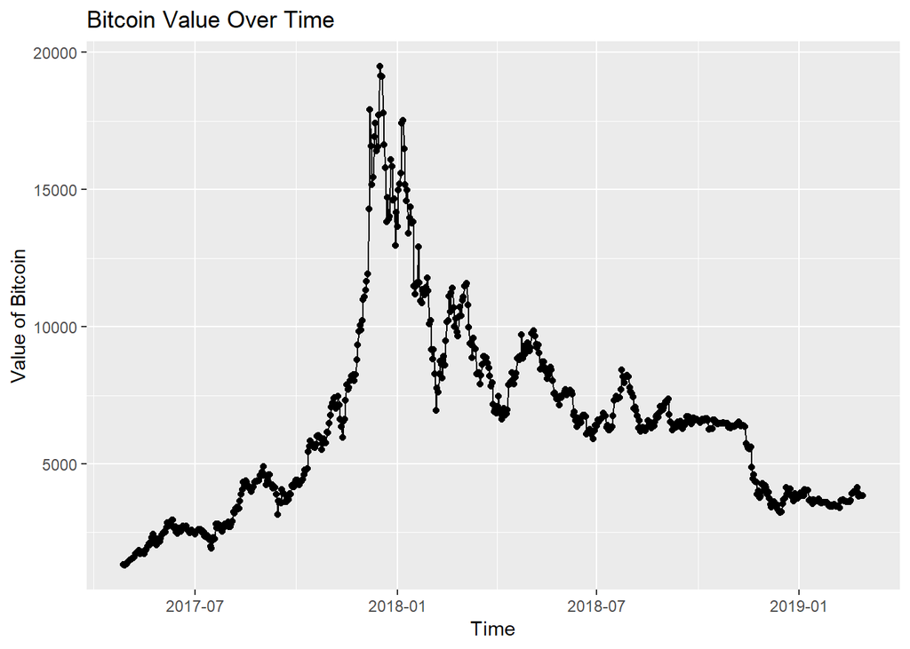

```r
crypto_data %>%
  ggplot(aes(x=Date, y=close)) +
    geom_point() +
    geom_line() +
    labs(title="Bitcoin Value Over Time",
         x = "Time",
         y = "Value of Bitcoin")
```

In order to analyze what determines the price of Bitcoin, we will use a logarithmic regression. The reason we will be performing a logarithmic regression rather than a linear regression is due the exponential nature of the price of Bitcoin. This can be seen in the plot, which was created using the function ‘ggplot’ with the x-axis being Time and the y-axis being the Value of Bitcoin.

We will run a regression with the closing price of Bitcoin, close, as our dependent variable. This will be used to represent the value of Bitcoin. This will be logged due to its exponential nature. To log a variable, use the ‘log’ function. We will also log several of the independent variables due to their exponential nature.

From the data set, crypto_data, we selected various variables as we believe that they may have an affect on the value of Bitcoin. Here is our intuition:

Volume: Indicates the amount of money people are putting into the Bitcoin system. The larger the volume the more confident people are with the Bitcoin, which would increase its value.

Spread: Indicates how speculation could have an effect on the value of Bitcoin. This will be logged.

TxPerDay: The more transactions individuals are making through Bitcoin, the more accepting people are with Bitcoin, which would increase its value. This will be logged.

AvgFee: A higher fee would indicate a higher demand for Bitcoin, which may increase its value. This will be logged.

Hashrate: A higher hashrate indicates that more people are involved in the Bitcoin system as well as it being more secure. This will be logged.

Diff: The harder it is to mine a Bitcoin the less return on investment one would get to mine it possibly decreasing its value. This will be logged.

ResElec/CommElec: Input costs to mine Bitcoin. A higher price in electricity may decrease the value of Bitcoin

FFR: Higher interest rates means that miners can not borrow much money to pay for hardware to mine Bitcoin, which may decrease the value of Bitcoin.

Trending: The popularity of Bitcoin may affect its price. This will be logged.

Infl: Chosen as a macroeconomic indicator of the impact of price changes on Bitcoin value

DJI_Adjusted: Instrument for general health of the US economy. This will be logged.

NVDA_Adjusted: Chosen as an instrument for interest in Bitcoin mining. This will be logged.

```r
library(broom)
price_fit <- lm(log(close) ~ log(volume) + log(spread) + log(TxPerDay) + log(AvgFee) + log(Hashrate) + log(Diff) + ResElec + CommElec + FFR + log(Trending) + Infl + log(NVDA_Adjusted) + log(DJI_Adjusted), data = crypto_data)

price_fit %>%
  broom::tidy() %>%
  knitr::kable(digits=4)
```

| term | estimate | std.error | statistic | p.value |
| --- | --- | --- | --- | --- |
| (Intercept) | -1.1533 | 2.3432 | -0.4922 | 0.6227 |
| log(volume) | 0.4609 | 0.0237 | 19.4448 | 0.0000 |
| log(spread) | -0.0520 | 0.0135 | -3.8568 | 0.0001 |
| log(TxPerDay) | 0.0143 | 0.0450 | 0.3187 | 0.7501 |
| log(AvgFee) | 0.0833 | 0.0179 | 4.6561 | 0.0000 |
| log(Hashrate) | 0.1691 | 0.0583 | 2.9029 | 0.0038 |
| log(Diff) | 0.3484 | 0.0696 | 5.0029 | 0.0000 |
| ResElec | -0.2909 | 0.0448 | -6.4890 | 0.0000 |
| CommElec | 0.0547 | 0.0472 | 1.1597 | 0.2466 |
| FFR | -0.9278 | 0.0864 | -10.7435 | 0.0000 |
| log(Trending) | -0.1244 | 0.0127 | -9.7978 | 0.0000 |
| Infl | 0.3321 | 0.0315 | 10.5437 | 0.0000 |
| log(NVDA_Adjusted) | 0.3548 | 0.0651 | 5.4457 | 0.0000 |
| log(DJI_Adjusted) | -0.3693 | 0.2364 | -1.5623 | 0.1187 |

We will now perform a logarithmic regression based on the dependent and indenpendet variables that we have chosen. We will use the function ‘lm’ to do this. ‘lm’ is used to fit linear models and to perform regressions. The ‘lm’ function requires a formula in which we will input the regression we described using the data from crypto_data. We will set it to price_fit.

To view the results, we require the function ‘tidy’ from the broom package. This function will allow us to view the estimates for each of the independent variables of our regression. We will also use the function ‘kable’ to limit the number of decimals we view as we only do not require such a precise number in order to make our interpretations. These results will allow us to perform interpretations on the relationship between the value of Bitcoin and the independent variables as well as determine whether or not those variables have a significant effect on the value of Bitcoin.

## Interpretation

Depending on the model, there are different ways to interpret the results. Here are a few ways a model could be interpreted:

Model 1: $y = \beta_0 + \beta_1x$ Interpretation: If you change x by one, we’d expect y to change by $\beta_1 \\$

Model 2: $log(y) = \beta_0 + \beta_1x$ Interpretation: If we change x by 1 (unit), we’d expect our y variable to change by $\beta_1 * 100\\$ percent.

Model 3: $y = \beta_0 + \beta_1log(x)$ Interpretation: If we increase x by one percent, we expect y to increase by $\beta_1/100$ units of y.

Model 4: $log(y) = \beta_0 + \beta_1log(x)$ Interpretation: If we increase x by one percent, we expect y to increase by $\beta_1$ percent.

On average, holding everything else constant, a one percent increase in volume will increase the price of Bitcoin by .4609%.

On average, holding everything else constant, a one percent increase in spread will decrease the price of Bitcoin by .052%.

On average, holding everything else constant, a one percent increase in transactions per day will increase the price of Bitcoin by .0143%.

On average, holding everything else constant, a one percent increase in average fee will increase the price of Bitcoin by .0833%.

On average, holding everything else constant, a one percent increase in hashrate will increase the price of Bitcoin by .1691%.

On average, holding everything else constant, a one percent increase in difficulty will increase the price of Bitcoin by .3484%.

On average, holding everything else constant, a one cent increase in the price of residential electricity will decrease the price of Bitcoin by 29.09%.

On average, holding everything else constant, a one cent increase in the price of commerical electricity will increase the price of Bitcoin by 5.47%.

On average, holding everything else constant, a one unit increase in the federal funds rate will decrease the price of Bitcoin by 92.78%.

On average, holding everything else constant, a one percent increase in NVDA stock will increase the price of Bitcoin by .3548%.

On average, holding everything else constant, a one percent increase in DJI stock will decrease the price of Bitcoin by .3693%.

## Hypothesis Testing

We will now perform hypothesis testing on our independent variables. This is to help determine whether or not our variables are statistically significant. In other words, did our variables have a substantial effect on the value of Bitcoin? In this case, the null hypothesis is that a variable has no effect on the value of Bitcoin. The alternative hypothesis is that the variable does have an effect on the value of Bitcoin. In order to determine whether or not we should reject or fail to reject the null hypothesis, we will use the probability model given by the Central Limit Theorem. We will use a 95% rejection threshold in this determination. For example, for an estimate $\hat{p}$, if $P(Y\geq\hat{p})\geq .95$ we would reject the null hypothesis of no effect and accept the alternative hypothesis that there is an effect.

To determine whether or not we can reject the null hypothesis. We will be using the p-value of each estimate. If the p-value is greater than 0.05, we would fail to reject the null hypothesis. If the p-value is less than 0.05, we would reject the null hypothesis suggesting that the variable has significance.

Looking at the regression, we can see that the variables log(volume), log(spread), log(AvgFee), log(Hashrate), log(Diff), ResElec, FFR, log(trending), Infl, and log(NVDA) all have p-values that are less than 0.05. This means that these variables are statistically significance suggesting that they are variables that influence the price of Bitcoin. It can also be seen that the p-values for log(TxPerDay), CommElec, and log(DJI_Adjusted) are all greater than 0.05 meaning that we fail to reject the null hypothesis. This means that log(TxPerDay), CommElec, and log(DJI_Adjusted) do not have a significant effect on the value of Bitcoin.

## Random Forest

There are several limitations in using linear methods for classification. One is that it is limited in the partition of predictor space into regions. As a result, we will be using tree-based methods to better predict the determinants on the price of Bitcoin.

```r
set.seed(1234)
new_cryp <- na.omit(crypto_data)
train_indices <- sample(nrow(new_cryp), nrow(new_cryp)/2)
train_set <- new_cryp[train_indices,]
test_set <- new_cryp[-train_indices,]

library(randomForest)
```

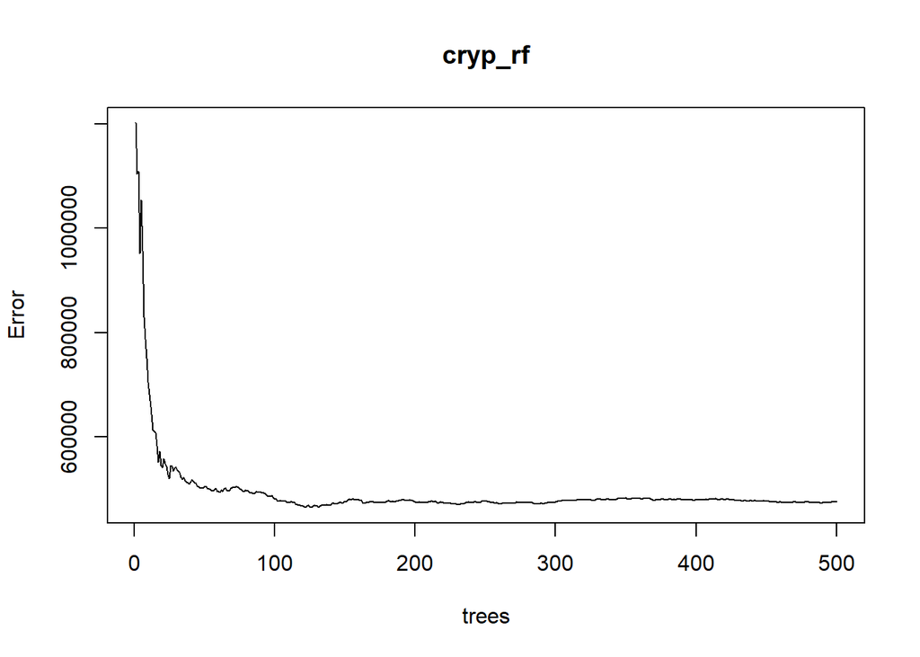

```r
cryp_rf <- randomForest(close ~ volume + spread + TxPerDay + AvgFee + Hashrate + Diff + ResElec + CommElec + FFR + Trending + Infl + NVDA_Adjusted + DJI_Adjusted, importance=TRUE, mtry=10, data=train_set)

plot(cryp_rf)
```

We will be using a random forest to predict which variables are the most important in affecting the value of Bitcoin. To do this, we must first have the randomForest package. A random forest does this by averaging multiple decision trees and by randomly selecting features to split.

Looking at the plot, we can see that the more trees that the random forest has, the smaller the error, which is improving its prediction accuracy.

```r
variable_importance <- importance(cryp_rf)
knitr::kable((round(variable_importance, digits=2)))
```

|  | %IncMSE | IncNodePurity |
| --- | --- | --- |
| volume | 19.27 | 494750277 |
| spread | 7.70 | 226265866 |
| TxPerDay | 6.87 | 30660186 |
| AvgFee | 13.13 | 48900010 |
| Hashrate | 12.49 | 39304061 |
| Diff | 34.89 | 326555619 |
| ResElec | 36.64 | 1547016986 |
| CommElec | 14.65 | 45230833 |
| FFR | 18.17 | 128893125 |
| Trending | 18.16 | 49476610 |
| Infl | 36.96 | 742413552 |
| NVDA_Adjusted | 12.04 | 96147453 |
| DJI_Adjusted | 8.16 | 14697508 |

Though we do lose interpretability when using a random forest, we are still able measure the variable importance from the random forest using the function ‘importance’.

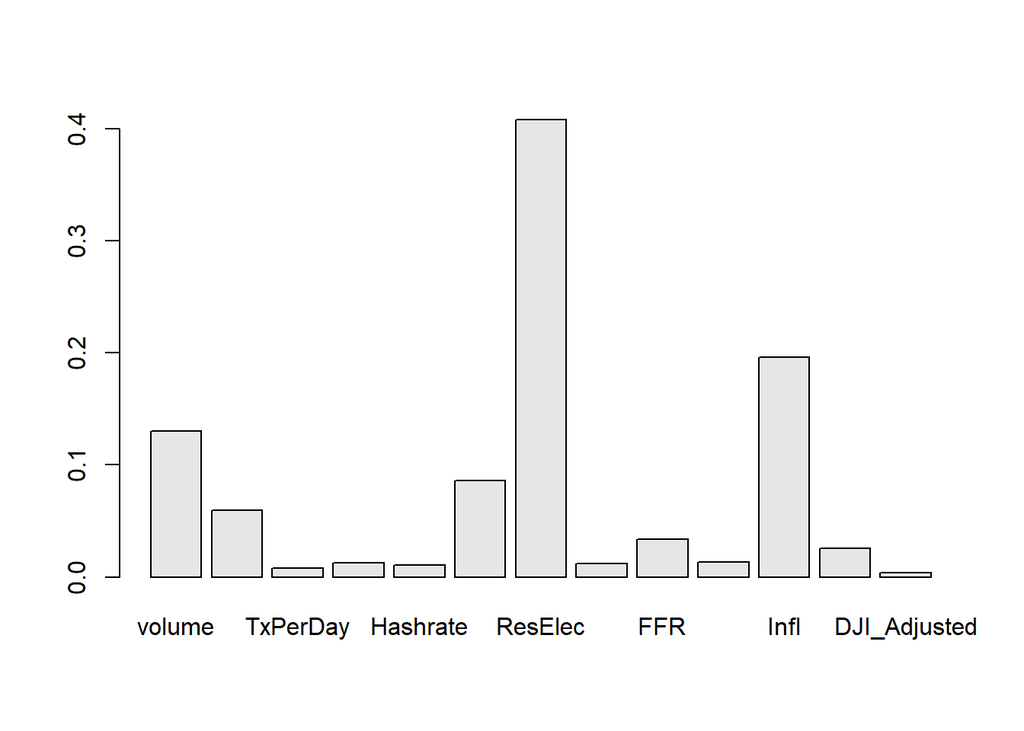

```r
barplot(t(variable_importance/sum(variable_importance)))
```

We can create a bar plot revealing how important a variable is in a random forest using the function ‘barplot’. From the bar plot, we can see that the variable, ResElec, is the most important variable indicating that the price if residential electricity greatly influences the value of Bitcoin. The second most important variable is inflation, infl, which indicates that macroeconomic factors have a major effect on the value of Bitcoin. Finally, the third most important variable in volume. This means that the amount of money in the Bitcoin system is an important aspect in determining the price of Bitcoin.

## Leaflet Visualization

```r
# need readxl library
library(readxl)

# read excel on local volume data in repository
volume_data <- read_excel("localvolumedata.xlsx")

# Our Data came out a bit wonky, so lets clean it up.
volume_data_df <- volume_data %>%
  as_data_frame()
# Regexpression
countryrexp <- "([A-Z]+[a-z]*)(\\s)*([A-Z]{1}[a-z]+)*.*"

# Clean up Country Data Values
# Change the name of some countries to make joining data easier
localvolumedata <- volume_data_df %>%
  mutate(Country = str_extract(Country,countryrexp))

# Change the name of some countries to make joining data easier
localvolumedata$Country[localvolumedata$Country == "USA"] <- "United States of America"
localvolumedata$Country[localvolumedata$Country == "Hong Kong"] <- "Hong Kong S.A.R."
localvolumedata$Country[localvolumedata$Country == "Tanzania"] <- "United Republic of Tanzania"
```

As a bonus, we will look at viewing certain types of geographical information with Leaflet in the context of Bitcoin. Specifically, we are observing Bitcoin Volume Data by Country.

Let’s read excel data again. You should find “localvolumedata.xlsx” in the repository. Our data may come out a bit wonky, so we’ll also clean it up. Note that country isn’t being formatted correctly.

```r
library(rgeos)
library(rworldmap)
library(leaflet)
library(rgdal)
library(jsonlite)
```

```r
library(xts)

# get world map
# note must also install rworldextra

wmap <- getMap(resolution= "high")

# get centroids
centroid <- gCentroid(wmap, byid=TRUE)

# get a data.frame with centroids
mapcen <- as.data.frame(centroid)

mapcen <- cbind(rownames(mapcen), mapcen)

rownames(mapcen) <- NULL
colnames(mapcen) <- c("Country", "Lng", "Lat")

maploc <- mapcen %>%
  mutate(Country = as.character(Country))


combined_map <- localvolumedata %>%
  inner_join(maploc, by = "Country")

combined_map <- combined_map %>%
  mutate(pcolor = case_when(
    Percentage < .001 ~ rgb(241/255,196/255,15/255),
    Percentage < .01  ~ rgb(243/255,156/255,18/255),
    Percentage < .1   ~ rgb(230/255,126/255,34/255),
    Percentage < .2   ~ rgb(211/255,84/255,0/255),
    Percentage >= .2   ~ rgb(135/255,54/255,0/255)
    ))

combined_map
```

| Country | Continent | Native Currency | FX Rate | USD Value | Percentage | Notes | Lng | Lat | pcolor |
| --- | --- | --- | --- | --- | --- | --- | --- | --- | --- |
| Argentina | South America | 244273785 | 3.5999999999999997E-2 | 8793856 | 0.0013904052 | NA | -65.178218 | -35.3826963 | #F39C12 |
| Australia | Australia | 254692234 | 0.73 | 185925331 | 0.0293968366 | NA | 134.492572 | -25.7323647 | #E67E22 |
| Brazil | South America | 114069866 | 0.26 | 29658165 | 0.0046892816 | NA | -53.093972 | -10.7827808 | #F39C12 |
| Canada | North America | 133970541 | 0.75 | 100477906 | 0.0158866603 | NA | -98.316063 | 61.3731260 | #E67E22 |
| Chile | South America | 6969942308 | 1.5E-3 | 10454913 | 0.0016530366 | NA | -71.355119 | -37.6960716 | #F39C12 |
| China | Asia | 4144788613 | 0.15 | 621718292 | 0.0983004895 | NA | 103.824910 | 36.5612765 | #E67E22 |
| Colombia | South America | 191729200301 | 3.4000000000000002E-4 | 65187928 | 0.0103069273 | NA | -73.080187 | 3.9109559 | #E67E22 |
| Croatia | Europe | 21760001 | 0.16 | 3481600 | 0.0005504792 | NA | 16.398662 | 45.0677604 | #F1C40F |
| Czech Republic | Europe | 95110449 | 4.4999999999999998E-2 | 4279970 | 0.0006767103 | NA | 15.314103 | 49.7324482 | #F1C40F |
| Denmark | Europe | 27742917 | 0.16 | 4438867 | 0.0007018336 | NA | 10.050670 | 55.9647168 | #F1C40F |

[output cut: 35 more lines]

Next, we need to get longitude and latitude data since it wasn’t included in our table. There are also some additional libraries that you might need to install.

Above lists out the code to get our longitude and latitude information for each country and combine it into a data-frame. Note that the conversion into the data-frame its columns to be labeled and of the right format.

Then we join our location data with our original excel table.

```r
ico <- awesomeIcons(
  icon = "bitcoin",
  library = "glyphicon",
  markerColor = "white",
  iconColor = combined_map$pcolor
)

colorspal <- c(rgb(241/255,196/255,15/255),rgb(243/255,156/255,18/255),rgb(230/255,126/255,34/255),rgb(211/255,84/255,0/255),rgb(135/255,54/255,0/255))


world_map <- leaflet(combined_map) %>%
  addTiles() %>%
  addAwesomeMarkers(~Lng,~Lat, icon = ~ico, popup = paste("<b>Country: </b> ", combined_map$Country, "<br>","<b>Continent: </b> ", combined_map$Continent, "<br>","<b>Native Currency: </b> ", combined_map$`Native Currency`, "<br>","<b>FX Rate: </b> ", combined_map$`FX Rate`, "<br>","<b>USD Value: </b> ", combined_map$`USD Value`, "<br>", "<b>Percentage: </b> ", combined_map$Percentage, "<br>"), clusterOptions = markerClusterOptions(), label = ~Country) %>%
  addLegend(labels = ~c("<b>x < 0.1%</b>","<b>x < 1%</b>","<b>x < 10%</b>","<b>x < 20%</b>","<b>x >= 20%</b>"), colors = ~colorspal, opacity = 1, title= "Volume Percentage")

world_map
```

[interactive chart not shown]

In order to set some visualization with leaflet, we must process our data by categorizing an attribute with color. Since we’re aiming to view Bitcoin Volume data of each country, we need to isolate an attribute that will be important in visualizing this data.

That attribute is the “Percentage” column of our new combined map. To categorize them with color, look at the code.

We also need to set icon info (you’ll see why in a bit) and create a matrix for our color values.

Now, we can get to embedding the map. We first need our tiles which it basically the background for the map. Then add some markers on the map to represent the information. Finally, we must add a legend.

Through this analysis on the price determinants of Bitcoin, hopefully this tutorial gave you insights on a few tools used by Data Scientists. We hope you learn to apply these skills on a project of your own and pursue growth in your respective field.